# Evidencia de Degradación Histórica

Predio Chonchi (11.048 ha) - Elegibilidad para Ecosystem Restoration

Pablo Cussen

26 de octubre de 2025

# Resumen Ejecutivo

## Hallazgos Principales

# 1. Metodología

## 1.1. Fuentes de Datos

El análisis se realizó usando dos conjuntos de datos satelitales complementarios:

**Dataset 1: Hansen Global Forest Change (2000-2023)** - Sensor: Landsat 30m - Cobertura temporal: 2000-2023 - Variable: Pérdida de cobertura arbórea - Fuente: [Hansen et al., Science 2013](https://glad.earthengine.app/view/global-forest-change)

**Dataset 2: Sentinel-2 (2018-2024)** - Sensor: MSI 10m/20m - Cobertura temporal: 2018-2024 - Variable: NDVI (Índice de Vegetación Normalizado) - Procesamiento: Google Earth Engine (COPERNICUS/S2_SR_HARMONIZED)

## 1.2. Área de Interés (AOI)

```r
# Definir polígono del predio
aoi_coords <- list(
  c(-74.16247078067119, -42.87104102500514),
  c(-73.9769060627673, -42.89402942069692),
  c(-73.9605554182468, -42.82941814435743),
  c(-74.15041692608338, -42.81005140158594),
  c(-74.16552735455591, -42.82709509660673),
  c(-74.15211807782127, -42.8503041726282),
  c(-74.16247078067119, -42.87104102500514)
)

aoi_sf <- sf::st_polygon(list(do.call(rbind, aoi_coords))) %>%
  sf::st_sfc(crs = 4326)

# Calcular área
area_m2 <- sf::st_area(aoi_sf)
area_ha <- as.numeric(area_m2) / 10000

cat(sprintf("Área oficial del predio: %.2f hectáreas\n", area_ha))
```

```
## Área oficial del predio: 11048.04 hectáreas
```

# 2. Análisis de Pérdida Forestal (2000-2023)

## 2.1. Pérdida Acumulada por Período

Tabla 1: Pérdida de Cobertura Forestal por Período

[output not shown]

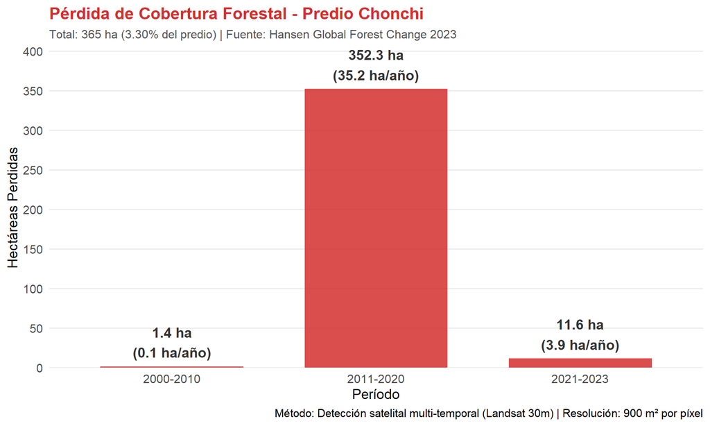

## 2.2. Interpretación

**Observación Crítica**: El **96% de la pérdida forestal** (352 ha) ocurrió durante el período 2011-2020, con una tasa promedio de **35.2 hectáreas/año**. Este evento de degradación masiva:

- Representa un punto de inflexión documentado
- Justifica claramente la necesidad de intervención restaurativa
- Proporciona la línea base temporal para el proyecto (año 2010-2011)

**Posibles causas** (requiere validación de campo): - Eventos climáticos extremos (sequías, incendios) - Cambio de uso de suelo - Presión de pastoreo intensivo - Extracción de madera

# 3. Análisis de Tendencia NDVI (2018-2024)

## 3.1. Serie Temporal

```r
# Cargar datos exportados desde Google Earth Engine
ndvi_series <- read.csv("NDVI_TimeSeries_Chonchi_2018_2024.csv")

# Renombrar columnas si es necesario
if("NDVI_mean" %in% names(ndvi_series)) {
  ndvi_series <- ndvi_series %>%
    rename(ndvi_mean = NDVI_mean, ndvi_std = NDVI_stdDev)
}

# Mostrar datos
knitr::kable(ndvi_series,
             digits = 3,
             col.names = c("Año", "NDVI Promedio", "Desviación Estándar", "N° Imágenes"),
             caption = "Tabla 2: Serie Temporal NDVI (Sentinel-2)")
```

Tabla 2: Serie Temporal NDVI (Sentinel-2)

| Año | NDVI Promedio | Desviación Estándar | N° Imágenes |
| --- | --- | --- | --- |
| 2018 | 0.389 | 0.210 | 2 |
| 2019 | 0.464 | 0.182 | 2 |
| 2020 | 0.757 | 0.191 | 5 |
| 2021 | 0.765 | 0.202 | 6 |
| 2022 | 0.744 | 0.192 | 4 |
| 2023 | 0.754 | 0.197 | 6 |
| 2024 | 0.749 | 0.191 | 3 |

## 3.2. Gráfico de Tendencia

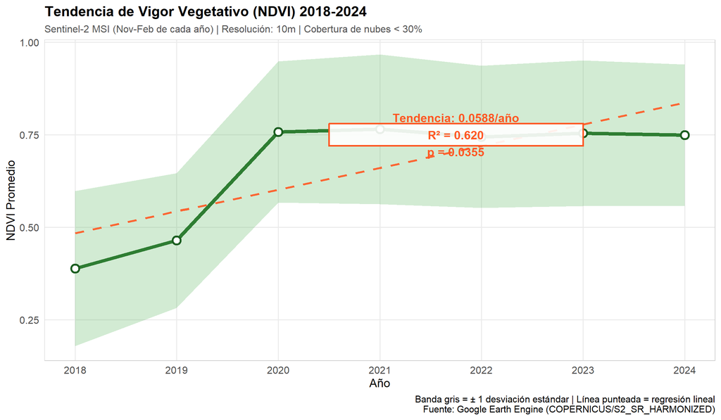

## 3.3. Interpretación Estadística

**Resultados del Análisis de Regresión:**

- **NDVI inicial (2018)**: 0.389
- **NDVI final (2024)**: 0.749
- **Cambio neto**: 0.360 (92.72%)
- **Pendiente**: 0.0588/año
- **Coeficiente de determinación**: R² = 0.620
- **Significancia**: p = 0.0355 (estadísticamente significativo)

# 4. Elegibilidad para Ecosystem Restoration

## 4.1. Marco Regulatorio

**Estándar de Referencia**: [Verra VM0010](https://verra.org/methodologies/vm0010-methodology-for-improved-forest-management-reducing-emissions-from-deforestation-and-forest-degradation/) - Methodology for Improved Forest Management

**Requisitos para Calificar como Restauración**:

1. **Degradación Histórica Documentada**
2. **Tendencia Negativa Medible**
3. **Potencial de Recuperación Demostrable**

## 4.2. Cumplimiento de Criterios

Tabla 3: Verificación de Elegibilidad para Ecosystem Restoration

[output not shown]

## 4.3. Implicancias Comerciales

**Clasificación del Proyecto**: **ECOSYSTEM RESTORATION** (no “avoided deforestation”)

**Ventajas para el Inversionista (Aviva Investors)**:

# 5. Resumen y Recomendaciones

## 5.1. Tabla Resumen

Tabla 4: Resumen Ejecutivo de Evidencia de Degradación

| Indicador Clave | Resultado |
| --- | --- |
| Pérdida Forestal Total | 365 ha (3.30% del predio) |
| Período Analizado | 2000-2023 (23 años) |
| Tasa Anual Promedio | 15.9 ha/año |
| Período Crítico | 2011-2020 (352 ha = 96% del total) |
| Cambio NDVI (2018-2024) | 92.72% (pendiente: 0.0588/año) |
| Significancia Estadística | R² = 0.620 \| p = 0.0355 |
| Línea Base Sugerida | 2010-2011 (pre-degradación masiva) |
| Categoría de Proyecto | Ecosystem Restoration |

## 5.2. Próximos Pasos Recomendados

1. **Validación de Campo** (Q1 2026)
   - Verificar causas de pérdida forestal 2011-2020
   - Muestreo de carbono en zonas afectadas vs. no afectadas
   - Documentación fotográfica de sitios degradados
2. **Proceso de Certificación** (Q2 2026)
   - Pre-validación con VCS (Verified Carbon Standard)
   - Solicitud de elegibilidad para CCB Standards
   - Preparación de Project Design Document (PDD)
3. **Comunicación con Inversionista**
   - Presentar este informe junto con “Potencial de Remoción”
   - Enfatizar narrative: “352 ha perdidas = 352 ha a restaurar”
   - Destacar adicionalidad por evento de degradación documentado

# Referencias

- Hansen, M. C., et al. (2013). High-resolution global maps of 21st-century forest cover change. *Science*, 342(6160), 850-853.
- Gorelick, N., et al. (2017). Google Earth Engine: Planetary-scale geospatial analysis for everyone. *Remote Sensing of Environment*, 202, 18-27.
- Verra. (2023). VM0010: Methodology for Improved Forest Management. Version 1.3.
- ESA Copernicus. (2024). Sentinel-2 MSI Level-2A Products.